# IE360 Project

## 6. Moving Average Method

Among the techniques used is perhaps the simplest Moving Average method after the naive model. As a result, the average of a certain number of data lasting is taken to predict the future. This method seems more successful than other methods. Of course, there are points where this model has difficulty in predicting. In addition to the aspects or other data that should be taken into consideration, much better estimates can be made.

```r
#MOVNG_AVERAGE

predictionDay1 <- 1:24
for(i in 1:24){
predictionDay1[i] <- data_production[data_production$date == "2022-05-23" & data_production$hour == 0+i-1, "production"]
}
predictionDay2 <- 1:24
for(i in 1:24){
predictionDay2[i] <- data_production[data_production$date == "2022-05-19" & data_production$hour == 0+i-1, "production"]
}
predictionDay3 <- 1:24
for(i in 1:24){
predictionDay3[i] <- data_production[data_production$date == "2022-05-18" & data_production$hour == 0+i-1, "production"]
}
predictionDay4 <- 1:24
for(i in 1:24){
predictionDay4[i] <- data_production[data_production$date == "2022-05-17" & data_production$hour == 0+i-1, "production"]
}

#FOR LAST 4 DAYS
predictionDay <- (predictionDay1+predictionDay2+predictionDay3 + predictionDay4)/4
predictionDay
```

```
##  [1]  0.0000  0.0000  0.0000  0.0000  0.0000  0.0900  5.2400 24.4825 34.9975
## [10] 35.0000 35.0000 34.4300 33.9550 28.1125 24.6525 25.6425 18.0125 16.7750
## [19]  6.1550  0.8400  0.0000  0.0000  0.0000  0.0000
```

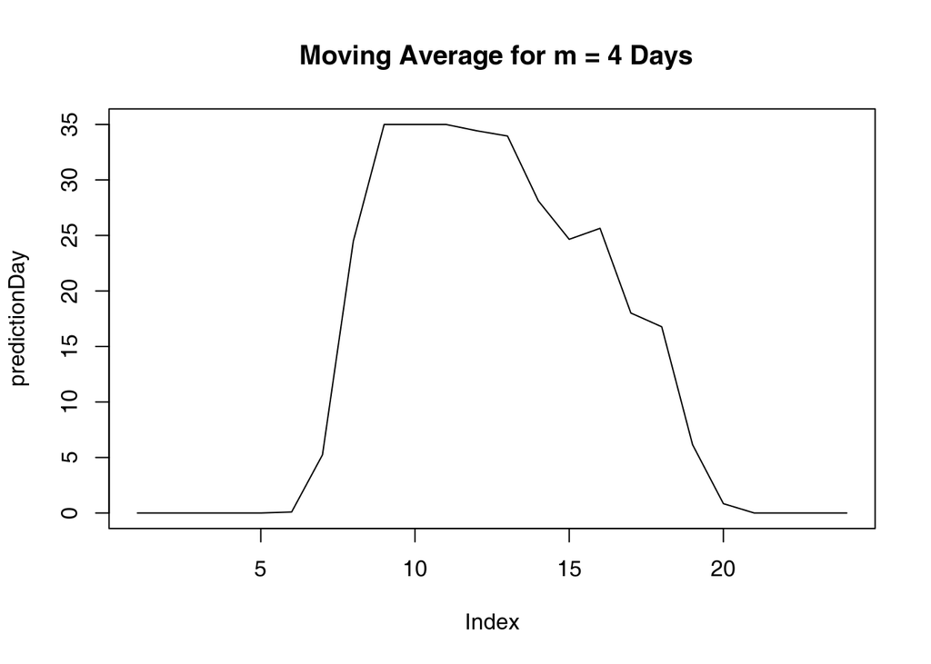

```r
plot(predictionDay,type="line", main = " Moving Average for m = 4 Days")
```

```r
#FOR LAST 2 DAYS
predictionDayx <- (predictionDay1+predictionDay2)/2
predictionDayx
```

```
##  [1]  0.000  0.000  0.000  0.000  0.000  0.120  6.330 26.490 35.000 35.000
## [11] 35.000 33.860 33.055 22.745 28.015 24.750 15.650 21.055  7.255  1.085
## [21]  0.000  0.000  0.000  0.000
```

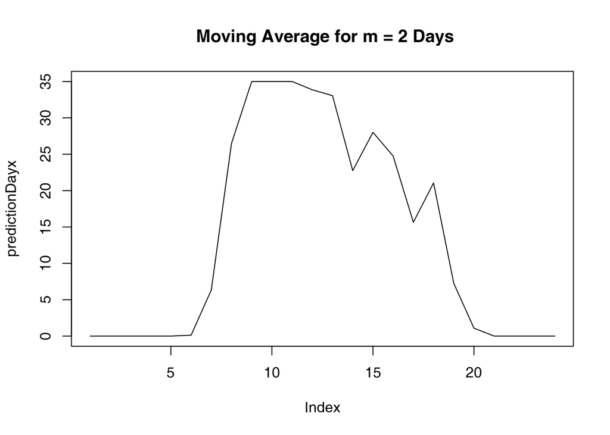

```r
plot(predictionDayx, type="line", main = " Moving Average for m = 2 Days")
```